# Sex Chromosome Size & Lifespan

### **Does the difference in sex chromosome size between homogametic and heterogametic individuals in a species contribute to the difference in lifespan between those individuals?**

##### This is a follow-up study to a study done on lifespan difference in homogametic and heterogametic individuals across the kingdom Animalia. Xirocostas et. al (2020) found that individuals of the heterogametic sex, or the sex with the reduced sex chromosome, live shorter lives than their homogametic counterparts. We wanted to know if the size difference between sex chromosomes has any correlation with the difference in lifespan.

##### Rather than tracking down measurements for the individual chromosomes, we gathered data on the size of entire genomes from genomesize.com for the species studied. *Drosophila* genome sizes came from work Dr. Hjelmen had previously done, and longevity data for those species came from studies done by Schnebel and Grossfield (1983) and Ma et. al (2018). Genome size and lifespan differences were calculated by subtracting the heterogametic values from the homogametic values.

##### Here’s a glimpse at the data:

```
## Rows: 41
## Columns: 14
## $ class                  <chr> "Arachnida", "Aves", "Aves", "Aves", "Aves", "I…
## $ order                  <chr> "Ixodida", "Anseriformes", "Passeriformes", "Pi…
## $ family                 <chr> "Ixodidae", "Anatidae", "Corvidae", "Picidae", …
## $ species                <chr> "Amblyomma cajennense", "Mergus merganser", "Ap…
## $ sex_determination      <chr> "male heterogametic", "female heterogametic", "…
## $ heterogametic_lifespan <dbl> 641.20, 13.80, 4.82, 3.08, 12.20, 46.10, 9.75, …
## $ homogametic_lifespan   <dbl> 682.500, 12.500, 4.520, 4.300, 7.100, 61.100, 1…
## $ ln_r_rlifespan         <dbl> 0.06242111, -0.09893990, -0.06426190, 0.3336854…
## $ population_source      <chr> "captive", "wild", "wild", "wild", "wild", "cap…
## $ lifespan_data_type     <chr> "mean", "max", "mean", "mean", "mean", "mean", …
## $ gs_het_mb              <dbl> 2552.58, NA, 1515.90, NA, 1066.02, 5026.92, 120…
## $ gs_homo_mb             <dbl> 2982.90, 1956.00, 1545.24, 1652.82, NA, 5046.48…
## $ gs_diff_det_mb         <dbl> 860.64, NA, 58.68, NA, NA, 39.12, 61.20, 17.40,…
## $ lifespan_diff          <dbl> 41.300, -1.300, -0.300, 1.220, -5.100, 15.000, …
```

##### I started by plotting the genome size differences against the lifespan differences. There doesn’t seem to be any obvious correlation.

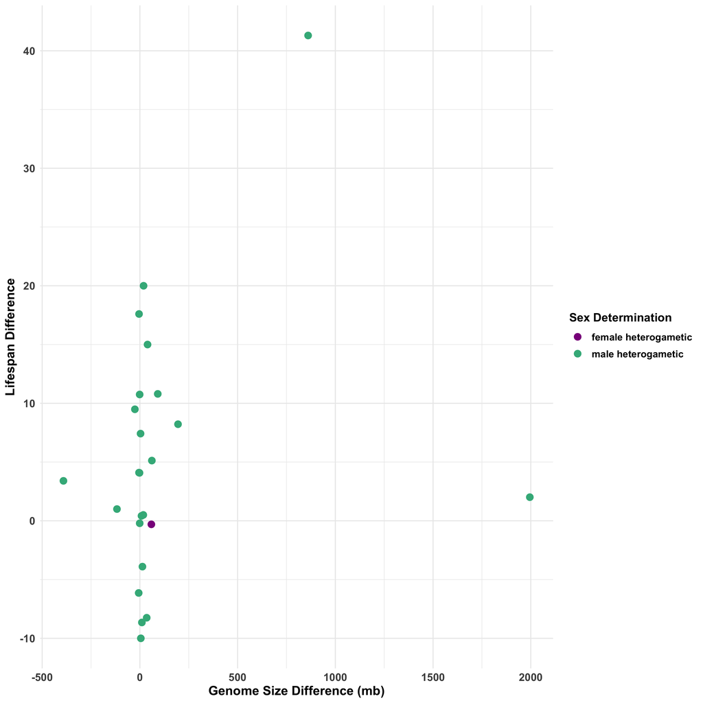

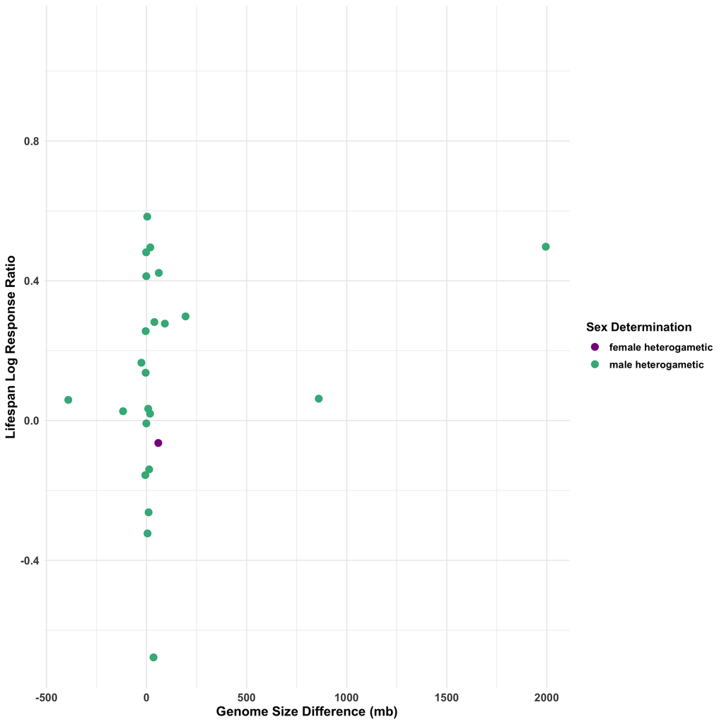

##### I put together a couple of models to see if there was any statistical significance. There didn’t appear to be.

###### Genome Size Difference and Lifespan Difference

```
##  [1] ""
##  [2] "Call:"
##  [3] "glm(formula = lifespan_diff ~ gs_diff_det_mb, data = .)"
##  [4] ""
##  [5] "Deviance Residuals: "
##  [6] "    Min       1Q   Median       3Q      Max  "
##  [7] "-14.500   -5.944   -0.364    5.324   31.883  "
##  [8] ""
##  [9] "Coefficients:"
## [10] "               Estimate Std. Error t value Pr(>|t|)  "
## [11] "(Intercept)    4.472740   2.329386    1.92   0.0679 ."
## [12] "gs_diff_det_mb 0.005745   0.005131    1.12   0.2750  "
## [13] "---"
## [14] "Signif. codes:  0 ‘***’ 0.001 ‘**’ 0.01 ‘*’ 0.05 ‘.’ 0.1 ‘ ’ 1"
## [15] ""
## [16] "(Dispersion parameter for gaussian family taken to be 121.2629)"
## [17] ""
## [18] "    Null deviance: 2819.8  on 23  degrees of freedom"
## [19] "Residual deviance: 2667.8  on 22  degrees of freedom"
## [20] "  (17 observations deleted due to missingness)"
## [21] "AIC: 187.17"
## [22] ""
## [23] "Number of Fisher Scoring iterations: 2"
## [24] ""
```

###### Genome Size Difference and Lifespan Log Response Ratio

```
##  [1] ""
##  [2] "Call:"
##  [3] "glm(formula = ln_r_rlifespan ~ gs_diff_det_mb, data = .)"
##  [4] ""
##  [5] "Deviance Residuals: "
##  [6] "     Min        1Q    Median        3Q       Max  "
##  [7] "-0.78351  -0.17583   0.03092   0.16782   0.48276  "
##  [8] ""
##  [9] "Coefficients:"
## [10] "                Estimate Std. Error t value Pr(>|t|)"
## [11] "(Intercept)    0.0999378  0.0635726   1.572    0.130"
## [12] "gs_diff_det_mb 0.0001671  0.0001400   1.193    0.246"
## [13] ""
## [14] "(Dispersion parameter for gaussian family taken to be 0.09032022)"
## [15] ""
## [16] "    Null deviance: 2.1156  on 23  degrees of freedom"
## [17] "Residual deviance: 1.9870  on 22  degrees of freedom"
## [18] "  (17 observations deleted due to missingness)"
## [19] "AIC: 14.315"
## [20] ""
## [21] "Number of Fisher Scoring iterations: 2"
## [22] ""
```

##### Looking at the plots and the models, there doesn’t appear to be any significant relationship in the lifespan difference and the sex chromosome size difference. However, more data might tell a different story.

##### References:

Ma, S., Avanesov, A. S., Porter, E., Lee, B. C., Mariotti, M., Zemskaya, N., Guigo, R., Moskalev, A. A., & Gladyshev, V. N. (2018). Comparative transcriptomics across 14 Drosophila species reveals signatures of longevity. Aging Cell, 17(4), e12740. https://doi.org/10.1111/acel.12740

Schnebel, E. M., & Grossfield, J. (1983). A comparison of life span characteristics in Drosophila. Experimental Gerontology, 18(5), 325–337. https://doi.org/10.1016/0531-5565(83)90011-6

Xirocostas, Z. A., Everingham, S. E., & Moles, A. T. (2020). The sex with the reduced sex chromosome dies earlier: A comparison across the tree of life. Biology Letters, 16(3), 20190867. https://doi.org/10.1098/rsbl.2019.0867

**Contact Info:**  
Marissa Ohran  
marissa.ohran@gmail.com